# Rmd Practice (Answers)

Ryan Safner

October 22, 2018

This is an `Rmd` file. Notice the syntax highlighting shows when you modify text or insert code, for example: **bold**, *italic*, and `code`. Edit the `YAML` header (above the `---`) to change the metadata like the `title`, `author`, and `date` to suit your purposes.

See my [R Markdown Guide](http://ryansafner.com/tutorial/RMDG) for more about `R Markdown`, and my [R for Econometrics Guide](http://ryansafner.com/tutorial/R4EH) for more on `R` commands for assistance. Look at both the `html` output of this guide and the raw `.Rmd` (which I expect you to edit), both are available on Blackboard and [GitHub](http://github.com/ryansafner/RMDG).

When you are ready, `knit` to `html` by clicking the **Knit** button at the top of the editor and it will compile the plain text and raw code into a lovely webpage. You should be able to knit to `html` right away (install packages if requested), but to knit to `pdf`, your computer first needs a $\LaTeX{}$ distribution in order to properly render a `pdf` via `tex`. So first, download from [MikTeX](http://miktex.org/download).

# Working with `R Markdown` Text and Syntax

Go through this [quick tutorial](https://www.markdowntutorial.com/) to practice the different syntax options for marking up text.

Now let’s try some other nice features of using `R Markdown`, beyind just running chunks of `R` code. This will also show you how you can use this as a way of working on other papers or projects, even if they do not need `R` or data analysis.

## Adding a bibliography and some citations

Create a new file `File -> New File -> Text File`. In principle, you could do this in any program, like Windows’ default `Notepad.` I recommend trying out [Bibdesk](https://bibdesk.sourceforge.io/). In any case, save this file as something, and make sure to end the name with `.bib`. Save it in the same folder on your computer as this `.Rmd` file.

Next, go to the `YAML` header at top of *this* document (between the `---`’s). Add a new line with `bibliography: mybibname.bib`, where `mybibname` is the name you gave to the new file. This tells `R Markdown` to pull citations from your `.bib` file, which must be in the same folder on your computer.

In the `.bib` file, copy/paste the following code:

```
@article{citekey1,
  author= {},
  year = {},
  title = {},
  journal = {},
  volume = {},
  number = {},
  pages = {}
}

@book{citekey2,
  author= {},
  year = {},
  title = {},
  publisher = {},
  address = {},
}
```

The first entry is an example entry for a journal article, and the second is for a book. Edit the content inside each `{}` with an example (feel free to make them up, as practice). Be sure to edit the `citekey1` and `citekey2` to something you will remember (I often do it as `authornameyear`), because these are what you type any time you want to include a citation to them. Edit in your citekeys below:

## Example Citations:

> “Here is an example quote from this article.” Smith and Jones (2018, 2)

Doe, Gibberish, and Fakerson (2016, 12) says “this short quote”, disagreeing with Smith and Jones (2018).

See also the references appear at the end of the document now (we just need to add a `# References` or `# Bibliography` at the end of the file to create a section for them). It lists all the references you cited in alphabetical order. You can [learn more](https://rmarkdown.rstudio.com/authoring_bibliographies_and_citations.html) about how to customize the format of the bibliography.

# Data and `R` Chunks

Here is a good place to continue practicing the data analysis we’ve been learning (importing data, making plots, regressions, tables, etc) and see the benefits of running `R` in chunks in a `R Markdown` document. Consider the remainder of this document just like the other **R Practice Problems** we’ve been doing in class, except now you understand how to do them right in the original file with my questions!

For each question, insert your answers between the triple asterisks `***` that create horizontal lines separating my questions from your answers. Remember, you can insert `R` chunks with the following format:

```r
# your code goes here
```

It’s easiest to use the **keyboard shortcut** `CTRL+ALT+I` (on Windows) `CMD+Option+I` (on Mac) to automatically create a blank `R` chunk for you.

Notice in the `.Rmd` file you can run just that “chunk” of code with the green play button. You can run all previous chunks in with the middle button. You can name your chunk and there are options you can set on each chunk, but they’re not important yet.

On to the questions:

### 1. Load the `econfreedom` dataset from Blackboard $\rightarrow$ data.

This is data I downloaded and cleaned up from the [Fraser Institute’s Economic Freedom Index](https://www.fraserinstitute.org/economic-freedom/dataset) and the [World Bank’s World Development Indicators](https://data.worldbank.org/indicator/NY.GDP.PCAP.CD), both great datasets. This data is in `.csv` format, so you can just download it somewhere and tell `R` to load it from the downloaded location with `df<-read.csv("/path/to/file.csv")` and save it to some dataframe object.

`ef` is a country’s (2014) overall Economic Freedom Index score from 0 (least free)-10 (most free). `gdp` is the country’s (2014) GDP per capita in USD.

```r
econfreedom<-read.csv("econfreedom.csv") # this is saved in the same folder in this repository
```

### 2. Look at the structure of the dataframe and print the first few rows.

```r
str(econfreedom)
```

```
## 'data.frame':    112 obs. of  6 variables:
##  $ X        : int  1 2 3 4 5 6 7 8 9 10 ...
##  $ Country  : Factor w/ 112 levels "Albania","Algeria",..: 1 2 3 4 5 6 7 8 9 10 ...
##  $ ISO      : Factor w/ 112 levels "AGO","ALB","ARG",..: 2 27 1 3 4 5 12 10 7 8 ...
##  $ ef       : num  7.4 5.15 5.08 4.81 7.93 7.56 7.6 6.35 7.51 6.22 ...
##  $ gdp      : num  4543 4784 4153 10502 54688 ...
##  $ continent: Factor w/ 5 levels "Africa","Americas",..: 4 1 1 2 5 4 3 3 4 1 ...
```

```r
head(econfreedom)
```

```
##   X   Country ISO   ef       gdp continent
## 1 1   Albania ALB 7.40  4543.088    Europe
## 2 2   Algeria DZA 5.15  4784.194    Africa
## 3 3    Angola AGO 5.08  4153.146    Africa
## 4 4 Argentina ARG 4.81 10501.660  Americas
## 5 5 Australia AUS 7.93 54688.446   Oceania
## 6 6   Austria AUT 7.56 47603.797    Europe
```

### 3. Get summary statistics of `ef` and `gdp`.

```r
summary(econfreedom$ef)
```

```
##    Min. 1st Qu.  Median    Mean 3rd Qu.    Max.
##   4.810   6.418   7.005   6.861   7.400   8.710
```

```r
summary(econfreedom$gdp)
```

```
##    Min. 1st Qu.  Median    Mean 3rd Qu.    Max.
##   206.7  1307.5  5123.3 14488.5 17302.7 89590.8
```

### 4. Enough manual labor, let’s crank up the automation.

Use `stargazer` to print a nice table of summary statistics for us automatically with `stargazer(data=mydf,type="html")`, where `mydf` is the name of your dataframe object. We can use `stargazer` both for regression tables (when your data object is a regression object) and for summary statistics tables (when it’s just a dataframe).

Edit the top of your `R` chunk to: `{r, results="asis"}`. This tells `R` to print the output of the chunk in the raw format `stargazer` creates, which we just set to `html`. This will look like a jumble of code until we `knit` the whole document into `html`, at which point it will be beautiful. Trust me.

If you want to see the output in a format you can understand right away, set `type="text"` in `stargazer`.

```r
library("stargazer")
stargazer(econfreedom, type="html")
```

| Statistic | N | Mean | St. Dev. | Min | Pctl(25) | Pctl(75) | Max |
| --- | --- | --- | --- | --- | --- | --- | --- |
| X | 112 | 56.500 | 32.476 | 1 | 28.8 | 84.2 | 112 |
| ef | 112 | 6.861 | 0.779 | 4.810 | 6.417 | 7.400 | 8.710 |
| gdp | 112 | 14,488.490 | 19,523.540 | 206.711 | 1,307.457 | 17,302.660 | 89,590.810 |

### 5. Load `ggplot2` and make a histogram of `ef` and of `gdp`.

Try changing the `R` chunk options to modify `fig.height` and `fig.width`.

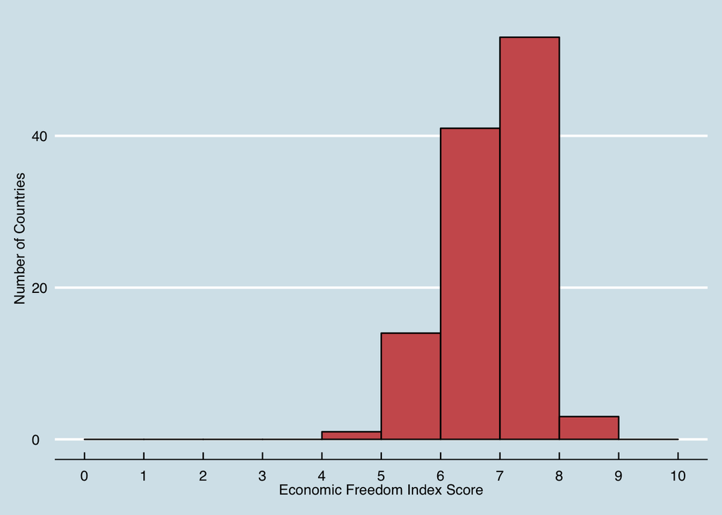

```r
library("ggplot2")
library("ggthemes")
ef.hist<-ggplot(data=econfreedom, aes(x=ef))+
  geom_histogram(breaks=seq(0,10,1),color="black",fill="indianred")+
  scale_x_continuous(breaks=seq(0,10,1))+xlab("Economic Freedom Index Score")+ylab("Number of Countries")+theme_economist()

ef.hist
```

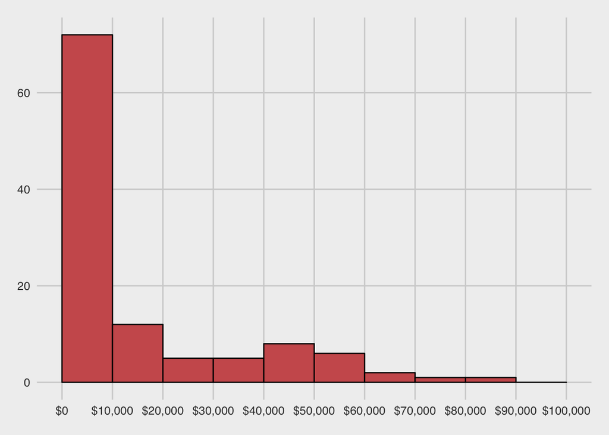

```r
gdp.hist<-ggplot(data=econfreedom, aes(x=gdp))+
  geom_histogram(breaks=seq(0,100000,10000),color="black",fill="indianred")+
  scale_x_continuous(breaks=seq(0,100000,10000),labels=scales::dollar)+xlab("Economic Freedom Index Score")+ylab("Number of Countries")+theme_fivethirtyeight()
gdp.hist
```

### 6. Now make a boxplot of `ef` and of `gdp` by `continent`.

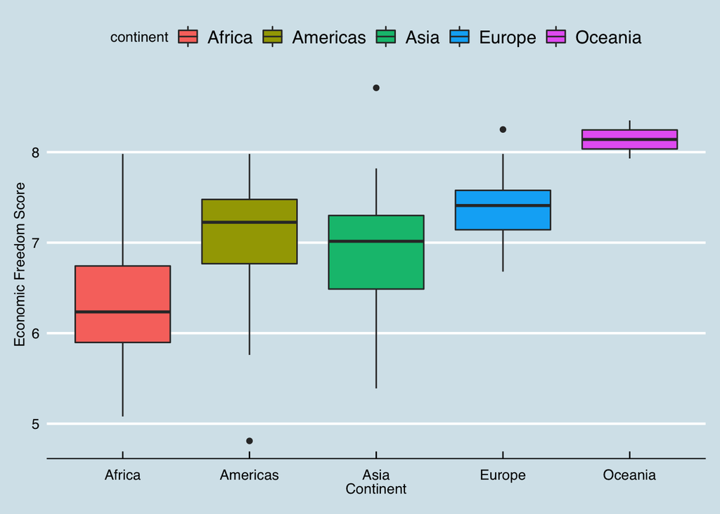

```r
ef.hist.cont<-ggplot(data=econfreedom, aes(x=continent,y=ef,fill=continent))+
  geom_boxplot()+
  scale_y_continuous(breaks=seq(0,10,1))+
  xlab("Continent")+ylab("Economic Freedom Score")+theme_economist()

ef.hist.cont
```

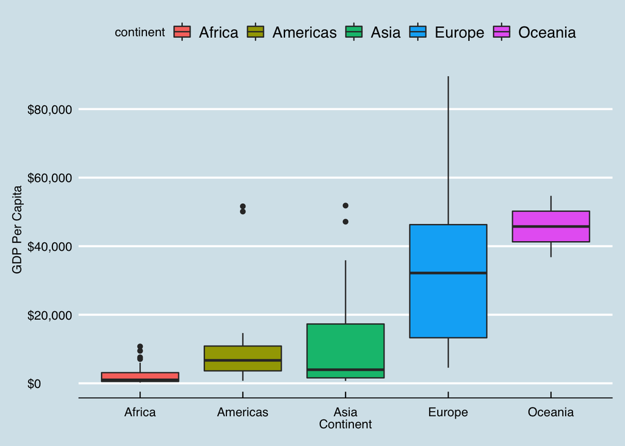

```r
gdp.hist.cont<-ggplot(data=econfreedom, aes(x=continent,y=gdp,fill=continent))+
  geom_boxplot()+
  scale_y_continuous(breaks=seq(0,100000,20000),labels=scales::dollar)+
  xlab("Continent")+ylab("GDP Per Capita")+theme_economist()
gdp.hist.cont
```

### 7. Now let’s consider the possible association between economic freedom ($X$) and GDP per capita ($Y$). Plot a scatterplot of the two.

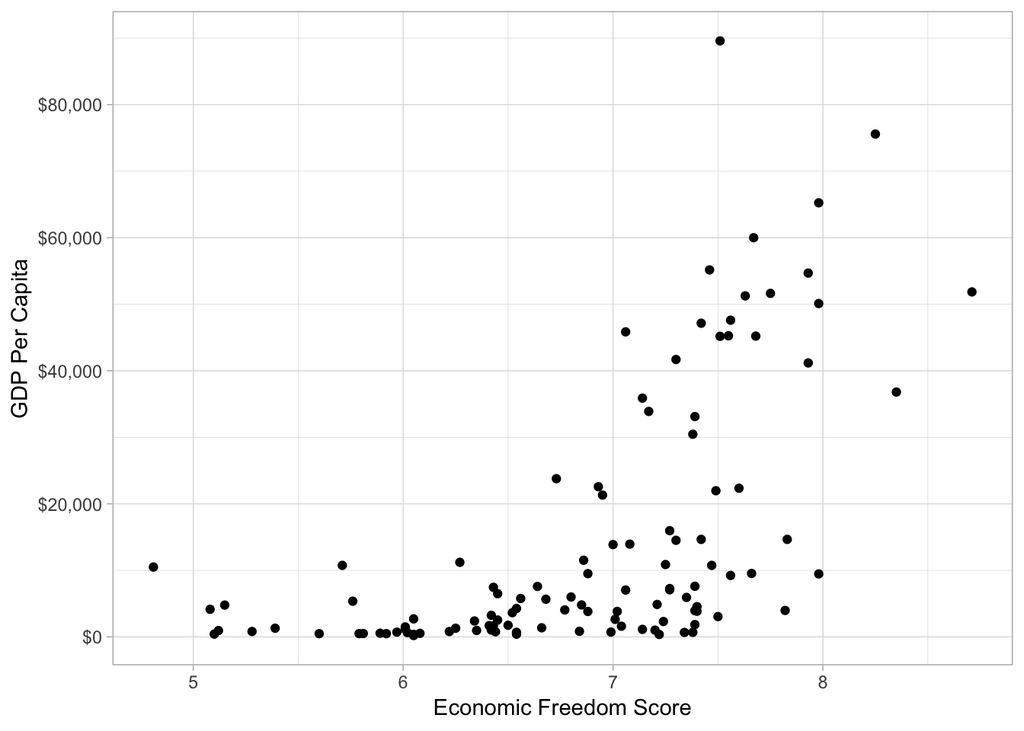

```r
scatter<-ggplot(data=econfreedom,aes(x=ef,y=gdp))+
  geom_point()+
  scale_x_continuous(breaks=seq(0,10,1))+xlab("Economic Freedom Score")+
  scale_y_continuous(breaks=seq(0,100000,20000),labels=scales::dollar)+
  ylab("GDP Per Capita")+theme_light()
scatter
```

#### a. Now re-plot scatterplot by continent. In the base layer, add `color=continent` to the aesthetics.

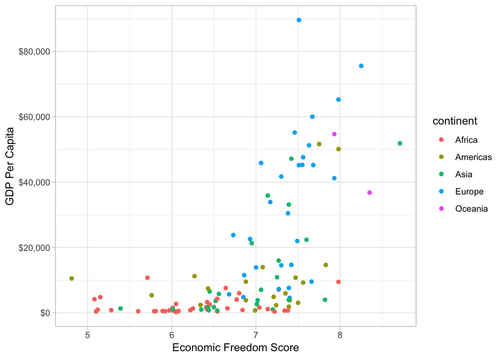

```r
scatter.cont<-ggplot(data=econfreedom,aes(x=ef,y=gdp, color=continent))+
  geom_point()+
  scale_x_continuous(breaks=seq(0,10,1))+xlab("Economic Freedom Score")+
  scale_y_continuous(breaks=seq(0,100000,20000),labels=scales::dollar)+
  ylab("GDP Per Capita")+theme_light()
scatter.cont
```

#### b. Alternatively, we could make separate plots for each continent by `facet`ing. Add to your original plot `+facet_grid(cols=vars(continent))`.

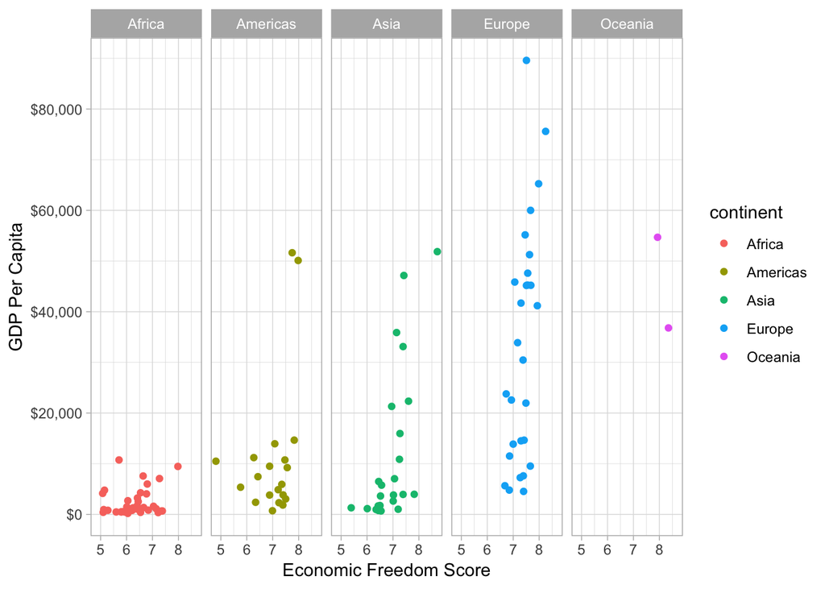

```r
scatter.facet<-scatter.cont+facet_grid(cols=vars(continent))
scatter.facet
```

### 8. Now let’s start considering whether higher economic freedom causes higher GDP per capita with the following simple model:

$$\widehat{gdp_i}=\hat{\beta_0}+\hat{\beta_1}ef_i$$
Take a moment to look at the $\LaTeX{}$ math code I used to generate that equation. Run the regression in `R` and get a `summary()` of it. What are:

- $\hat{\beta_0}$
- $SE(\hat{\beta_0})$
- $\hat{\beta_1}$
- $SE(\hat{\beta_1})$
- $R^2$
- $SER$

Write out the regression equation.

```r
reg<-lm(gdp~ef, data=econfreedom)
summary(reg)
```

```
##
## Call:
## lm(formula = gdp ~ ef, data = econfreedom)
##
## Residuals:
##    Min     1Q Median     3Q    Max
## -24612 -10511  -3707   9727  65562
##
## Coefficients:
##             Estimate Std. Error t value Pr(>|t|)
## (Intercept)   -86400      13362  -6.466 2.85e-09 ***
## ef             14704       1935   7.599 1.06e-11 ***
## ---
## Signif. codes:  0 '***' 0.001 '**' 0.01 '*' 0.05 '.' 0.1 ' ' 1
##
## Residual standard error: 15880 on 110 degrees of freedom
## Multiple R-squared:  0.3442, Adjusted R-squared:  0.3383
## F-statistic: 57.74 on 1 and 110 DF,  p-value: 1.063e-11
```

- $\hat{\beta_0}=-86400$
- $SE(\hat{\beta_0})=13362$
- $\hat{\beta_1}=14704$
- $SE(\hat{\beta_1})=1935$
- $R^2=0.3442$
- $SER=15880$

### 9. Test whether there is any relationship between `ef` and `gdp`.

I mostly intend for you to do this manually, interpretting the output of the regression in #8. However, you can also do this with the `lmtest` package’s `coeftest()` command, and your regression object in the parentheses.

- $H_0: \beta_1=0$
- $H_1: \beta_1 \neq 0$

The test statistic is

$$t=\frac{\hat{\beta_1}-H_0}{SE(\hat{\beta_1})}=\frac{14704-0}{1935} \approx 7.599$$

This is a quite large test statistic. `R` tells us the p-value is 1.06e-11, i.e. 0.00000000000106.

We can confirm with

```r
2*pt(7.599,df=110, lower.tail=FALSE) # probability of everything to the right of t=7.599
```

```
## [1] 1.060772e-11
```

```r
# with 110 df (remember, it's n-k-1 df = 112-1-1=110)
# times two, for a two-sided alternative
```

```r
library("lmtest")
coeftest(reg)
```

```
##
## t test of coefficients:
##
##             Estimate Std. Error t value  Pr(>|t|)
## (Intercept) -86400.1    13361.8 -6.4662 2.853e-09 ***
## ef           14704.3     1935.1  7.5986 1.063e-11 ***
## ---
## Signif. codes:  0 '***' 0.001 '**' 0.01 '*' 0.05 '.' 0.1 ' ' 1
```

### 10. Publish your regression output table with `stargazer`.

```r
library("stargazer")
stargazer(reg, type="html")
```

|  | *Dependent variable:* |
| --- | --- |
|  | gdp |
| ef | 14,704.300*** |
|  | (1,935.129) |
| Constant | -86,400.070*** |
|  | (13,361.770) |
| Observations | 112 |
| R<sup>2</sup> | 0.344 |
| Adjusted R<sup>2</sup> | 0.338 |
| Residual Std. Error | 15,881.920 (df = 110) |
| F Statistic | 57.739*** (df = 1; 110) |
| *Note:* | p<0.1; p<0.05; p<0.01 |

### 11. Europe seems to have the greatest variation. Subset your data to look only at Europe. Make a histogram of GDP, make a scatterplot like in #7, and run a regression, all only for European countries.

```r
europe<-subset(econfreedom,continent=="Europe")
```

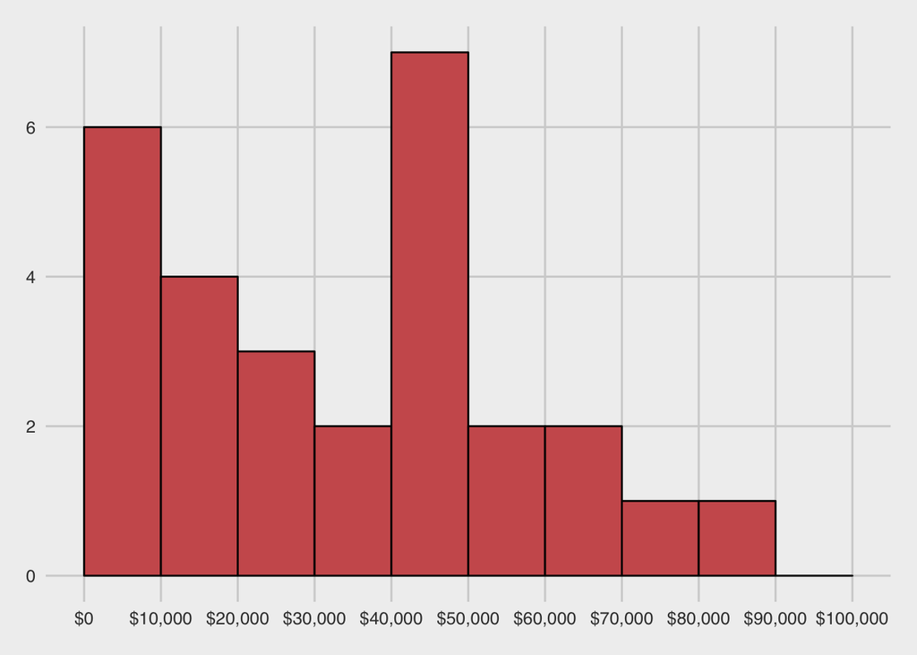

```r
euro.hist<-ggplot(data=europe, aes(x=gdp))+
  geom_histogram(breaks=seq(0,100000,10000),color="black",fill="indianred")+
  scale_x_continuous(breaks=seq(0,100000,10000),labels=scales::dollar)+xlab("Economic Freedom Index Score")+ylab("Number of Countries")+theme_fivethirtyeight()
euro.hist
```

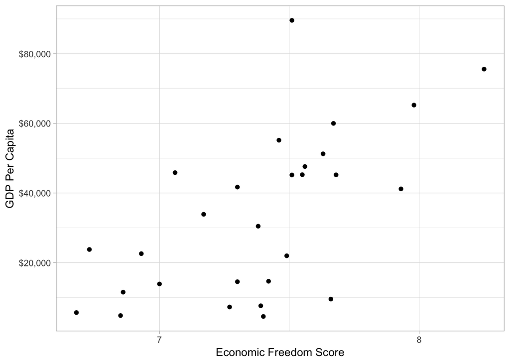

```r
euroscatter<-ggplot(data=europe,aes(x=ef,y=gdp))+
  geom_point()+
  scale_x_continuous(breaks=seq(0,10,1))+xlab("Economic Freedom Score")+
  scale_y_continuous(breaks=seq(0,100000,20000),labels=scales::dollar)+
  ylab("GDP Per Capita")+theme_light()
euroscatter
```

```r
eureg<-lm(gdp~ef,data=europe)
summary(eureg)
```

```
##
## Call:
## lm(formula = gdp ~ ef, data = europe)
##
## Residuals:
##    Min     1Q Median     3Q    Max
## -34535 -13772   2872   9040  51214
##
## Coefficients:
##             Estimate Std. Error t value Pr(>|t|)
## (Intercept)  -246884      70540  -3.500 0.001697 **
## ef             37984       9547   3.979 0.000494 ***
## ---
## Signif. codes:  0 '***' 0.001 '**' 0.01 '*' 0.05 '.' 0.1 ' ' 1
##
## Residual standard error: 18690 on 26 degrees of freedom
## Multiple R-squared:  0.3784, Adjusted R-squared:  0.3545
## F-statistic: 15.83 on 1 and 26 DF,  p-value: 0.0004944
```

### 12. Run similar regresions with only “Americas”, “Asia”, “Africa”, and “Oceania”, and then finally, print a regression table with `stargazer` with all of your models. Practice labelling the columns (each individual regression) by adding the options, `column.labels = c("All", "Europe", "Americas", "Asia", "Africa", "Oceania")`. Learn more about customizing `stargazer` with this [cheatsheet](https://www.jakeruss.com/cheatsheets/stargazer).

```r
americas<-subset(econfreedom,continent=="Americas")

americareg<-lm(gdp~ef,data=americas)
summary(americareg)
```

```
##
## Call:
## lm(formula = gdp ~ ef, data = americas)
##
## Residuals:
##    Min     1Q Median     3Q    Max
## -11787  -8159  -3937   2257  35681
##
## Coefficients:
##             Estimate Std. Error t value Pr(>|t|)
## (Intercept)   -34015      28749  -1.183    0.252
## ef              6448       4080   1.580    0.131
##
## Residual standard error: 13650 on 18 degrees of freedom
## Multiple R-squared:  0.1218, Adjusted R-squared:  0.07305
## F-statistic: 2.497 on 1 and 18 DF,  p-value: 0.1315
```

```r
asia<-subset(econfreedom,continent=="Asia")
asiareg<-lm(gdp~ef,data=asia)
summary(asiareg)
```

```
##
## Call:
## lm(formula = gdp ~ ef, data = asia)
##
## Residuals:
##    Min     1Q Median     3Q    Max
## -21233  -6000  -2070   4668  27958
##
## Coefficients:
##             Estimate Std. Error t value Pr(>|t|)
## (Intercept)   -92421      25670  -3.600 0.001590 **
## ef             15042       3686   4.081 0.000494 ***
## ---
## Signif. codes:  0 '***' 0.001 '**' 0.01 '*' 0.05 '.' 0.1 ' ' 1
##
## Residual standard error: 11860 on 22 degrees of freedom
## Multiple R-squared:  0.4309, Adjusted R-squared:  0.405
## F-statistic: 16.66 on 1 and 22 DF,  p-value: 0.0004945
```

```r
africa<-subset(econfreedom,continent=="Africa")
africareg<-lm(gdp~ef,data=africa)
summary(africareg)
```

```
##
## Call:
## lm(formula = gdp ~ ef, data = africa)
##
## Residuals:
##     Min      1Q  Median      3Q     Max
## -2734.0 -1472.9 -1230.5   776.9  8956.3
##
## Coefficients:
##             Estimate Std. Error t value Pr(>|t|)
## (Intercept)  -3141.3     3951.1  -0.795    0.432
## ef             864.6      624.4   1.385    0.175
##
## Residual standard error: 2660 on 36 degrees of freedom
## Multiple R-squared:  0.05056,    Adjusted R-squared:  0.02419
## F-statistic: 1.917 on 1 and 36 DF,  p-value: 0.1747
```

```r
stargazer(reg,eureg,americareg,asiareg,africareg, column.labels = c("All", "Europe", "Americas", "Asia", "Africa", "Oceania"), type="html")
```

|  | *Dependent variable:* |  |  |  |  |
| --- | --- | --- | --- | --- | --- |
|  | gdp |  |  |  |  |
|  | All | Europe | Americas | Asia | Africa |
|  | (1) | (2) | (3) | (4) | (5) |
| ef | 14,704.300*** | 37,984.170*** | 6,448.031 | 15,042.190*** | 864.610 |
|  | (1,935.129) | (9,547.197) | (4,080.320) | (3,685.486) | (624.428) |
| Constant | -86,400.070*** | -246,884.500*** | -34,014.730 | -92,421.130*** | -3,141.302 |
|  | (13,361.770) | (70,539.970) | (28,749.250) | (25,670.190) | (3,951.120) |
| Observations | 112 | 28 | 20 | 24 | 38 |
| R<sup>2</sup> | 0.344 | 0.378 | 0.122 | 0.431 | 0.051 |
| Adjusted R<sup>2</sup> | 0.338 | 0.355 | 0.073 | 0.405 | 0.024 |
| Residual Std. Error | 15,881.920 (df = 110) | 18,689.560 (df = 26) | 13,651.880 (df = 18) | 11,860.160 (df = 22) | 2,659.794 (df = 36) |
| F Statistic | 57.739*** (df = 1; 110) | 15.829*** (df = 1; 26) | 2.497 (df = 1; 18) | 16.658*** (df = 1; 22) | 1.917 (df = 1; 36) |
| *Note:* | p<0.1; p<0.05; p<0.01 |  |  |  |  |

Sometimes we don’t want to show the code along with our results. In the chunk below, change the options to `{r, echo=FALSE}`. `echo` asks (logically, `TRUE` or `FALSE`) if you want to also print the raw input code along with `R`’s output.

```
## [1] 4
```

To change **all** chunks to not print the raw input codes, go to the very first chunk called `setup` at the top. `R` will always run this chunk first, and it can be used to set default options for *all* successive chunks. Edit it to say `knitr::opts_chunk$set(echo = FALSE)`. This is particularly helpful if you are writing an paper in a single `.Rmd` file and don’t want any code in the final version.

# Bibliography

Doe, John, Erica Gibberish, and Frank Fakerson. 2016. *How Did This Get Published?* New York, NY: Sketchy Publishing, Inc.

Smith, Robert, and Anne Jones. 2018. “A Test Article.” *Fake Articles Quarterly* 12 (2): 1–21.